# Hooq Assignment

Arka Gupta

20 November 2016

## Step 1 : Data Aggregation

We aggregate the data using Google BigQuery. Here is the query for the same : “SELECT acc_acct_id AS UserID, country AS Country, COUNT( acc_acct_id ) AS Frequency, MAX( days_since_activation ) AS Day_since_activation, INTEGER(SUM( event_duration )) AS Total_Watchtime, COUNT(DISTINCT( device_type + device_os_platform )) AS No_of_Device, COUNT(DISTINCT( content_id )) AS No_of_contents, COUNT(DISTINCT( content_genre )) AS No_of_contentgenre, COUNT(DISTINCT( content_language )) AS No_of_Languages, FROM [green-tv:Test.finaldata] group by 1,2 order by 1”

So the new columns are : 1. UserID - Unique Customer Id 2. Country - Country of the user 3. Frequency - Number of times user visited the platform. 4. Day_since_activation - Number of days since the User registered 5. Total_watchtime - Total number of minutes the user engaged in the platform. 6. No_of_Device - Number of device the user used to access the platform. 7. No_of_contents - Number of content that the user viewed. 8. No_of_contentgenre - Number of types of contents the user viewed. 9. No_of_Languages - Number of languages of content that the user viewed.

At first we are going to import the data and format the data types.

```r
formatdata <- read.csv("/home/arka/Downloads/Finaldata.csv",header = TRUE)
formatdata[,1]<-as.factor(formatdata[,1])
formatdata$Country<- as.factor(formatdata$Country)
summary(formatdata)
```

```
##      UserID      Country     Frequency       Day_since_activation
##  22554  :    1   1:23684   Min.   :  1.000   Min.   :  0.00
##  23013  :    1   2: 1473   1st Qu.:  1.000   1st Qu.:  1.00
##  23332  :    1   3:19339   Median :  2.000   Median :  5.00
##  23994  :    1   4:10742   Mean   :  5.224   Mean   : 31.45
##  24004  :    1             3rd Qu.:  5.000   3rd Qu.: 27.00
##  24057  :    1             Max.   :329.000   Max.   :399.00
##  (Other):55232
##  Total_Watchtime   No_of_Device   No_of_contents    No_of_contentgenre
##  Min.   :   0.0   Min.   :1.000   Min.   :  1.000   Min.   : 1.000
##  1st Qu.:   1.0   1st Qu.:1.000   1st Qu.:  1.000   1st Qu.: 1.000
##  Median :  11.0   Median :1.000   Median :  2.000   Median : 1.000
##  Mean   : 101.3   Mean   :1.047   Mean   :  4.186   Mean   : 2.562
##  3rd Qu.:  94.0   3rd Qu.:1.000   3rd Qu.:  4.000   3rd Qu.: 3.000
##  Max.   :6315.0   Max.   :5.000   Max.   :266.000   Max.   :83.000
##
##  No_of_Languages
##  Min.   :1.0
##  1st Qu.:1.0
##  Median :1.0
##  Mean   :1.3
##  3rd Qu.:2.0
##  Max.   :8.0
##
```

```r
nrow(formatdata)
```

```
## [1] 55238
```

## Step 2 : Sample the dataset

We are going to sample 30% of the data for our analysis, assuming that the provided data is representing the whole population in the platform for 4 countries.

```r
sample_formatdata <- formatdata[sample(1:nrow(formatdata), 15000,replace=FALSE),]
summary(sample_formatdata)
```

```
##      UserID      Country    Frequency       Day_since_activation
##  23013  :    1   1:6485   Min.   :  1.000   Min.   :  0.0
##  23332  :    1   2: 389   1st Qu.:  1.000   1st Qu.:  1.0
##  24304  :    1   3:5242   Median :  2.000   Median :  5.0
##  25615  :    1   4:2884   Mean   :  5.271   Mean   : 30.1
##  31229  :    1            3rd Qu.:  5.000   3rd Qu.: 27.0
##  31304  :    1            Max.   :329.000   Max.   :399.0
##  (Other):14994
##  Total_Watchtime   No_of_Device   No_of_contents    No_of_contentgenre
##  Min.   :   0.0   Min.   :1.000   Min.   :  1.000   Min.   : 1.000
##  1st Qu.:   1.0   1st Qu.:1.000   1st Qu.:  1.000   1st Qu.: 1.000
##  Median :  11.0   Median :1.000   Median :  2.000   Median : 1.000
##  Mean   : 101.9   Mean   :1.048   Mean   :  4.219   Mean   : 2.591
##  3rd Qu.:  94.0   3rd Qu.:1.000   3rd Qu.:  4.000   3rd Qu.: 3.000
##  Max.   :6315.0   Max.   :4.000   Max.   :266.000   Max.   :83.000
##
##  No_of_Languages
##  Min.   :1.0
##  1st Qu.:1.0
##  Median :1.0
##  Mean   :1.3
##  3rd Qu.:2.0
##  Max.   :8.0
##
```

# Step 3 : Normalization

We are going to normalize the data and calculate the euclidean distance between variables which will be needed for applying the Clustering technique. We will also remove the categorical variables and create a newdataset for apllying cluster algorithm.

```r
z <- sample_formatdata[,-c(1,2)]
m <- apply(z,2,mean)
s <- apply(z,2,sd)
normal <- scale(z,m,s)
distance <- dist(normal)
```

## Step 4 : Applying clustering technique

At first we will run hierarchial cluster to figure number of clusters by help of Screeplot. Then we will apply Kmeans cluster to define our final clusters.

```r
hc.c <- hclust(distance)
wss <- (nrow(z)-1)*sum(apply(z,2,var))
for (i in 2:20) wss[i] <- sum(kmeans(z,centers = i)$withinss)
```

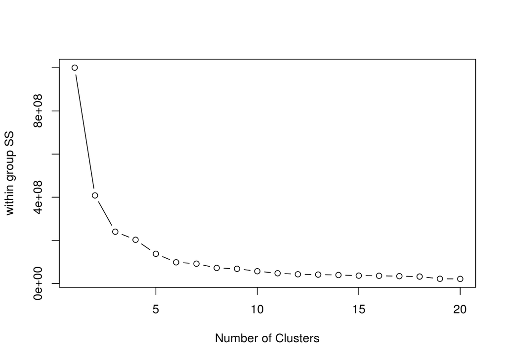

```r
plot(1:20,wss,type = "b",xlab = "Number of Clusters",ylab = "within group SS")
```

Here we can see that the first 3 clusters are able to represent most of the variance in the dataset. So we will go for 3 clusters.

## Step 5 : Applying Kmeans cluster(3)

Now we will apply kmeans cluster and find out about the cluster centers or how the variables could be explained within individual clusters :

```r
kc <- kmeans(z,3)
kc$centers
```

```
##   Frequency Day_since_activation Total_Watchtime No_of_Device
## 1  3.333627             28.15899        41.53477     1.038628
## 2 56.798969             44.28866      1683.25258     1.175258
## 3 19.057191             49.98823       535.59882     1.140454
##   No_of_contents No_of_contentgenre No_of_Languages
## 1       2.603731           2.072189        1.257032
## 2      47.757732          13.226804        1.814433
## 3      15.616484           6.791421        1.712363
```

## Step 6 : Export data to visualize

```r
finald <- sample_formatdata
finald["cluster"] <- as.factor(kc$cluster)
summary(finald)
```

```
##      UserID      Country    Frequency       Day_since_activation
##  23013  :    1   1:6485   Min.   :  1.000   Min.   :  0.0
##  23332  :    1   2: 389   1st Qu.:  1.000   1st Qu.:  1.0
##  24304  :    1   3:5242   Median :  2.000   Median :  5.0
##  25615  :    1   4:2884   Mean   :  5.271   Mean   : 30.1
##  31229  :    1            3rd Qu.:  5.000   3rd Qu.: 27.0
##  31304  :    1            Max.   :329.000   Max.   :399.0
##  (Other):14994
##  Total_Watchtime   No_of_Device   No_of_contents    No_of_contentgenre
##  Min.   :   0.0   Min.   :1.000   Min.   :  1.000   Min.   : 1.000
##  1st Qu.:   1.0   1st Qu.:1.000   1st Qu.:  1.000   1st Qu.: 1.000
##  Median :  11.0   Median :1.000   Median :  2.000   Median : 1.000
##  Mean   : 101.9   Mean   :1.048   Mean   :  4.219   Mean   : 2.591
##  3rd Qu.:  94.0   3rd Qu.:1.000   3rd Qu.:  4.000   3rd Qu.: 3.000
##  Max.   :6315.0   Max.   :4.000   Max.   :266.000   Max.   :83.000
##
##  No_of_Languages cluster
##  Min.   :1.0     1:13617
##  1st Qu.:1.0     2:  194
##  Median :1.0     3: 1189
##  Mean   :1.3
##  3rd Qu.:2.0
##  Max.   :8.0
##
```